# presentation

# R Workshop

### Module 4: Data visualization with R (1)

2018-04-11  
Bobae Kang  
(Bobae.Kang@illinois.gov)

### Agenda

- Part 1: The Grammar of Graphics
- Part 2: Maps and Interactive Plots

## The Grammar of Graphics

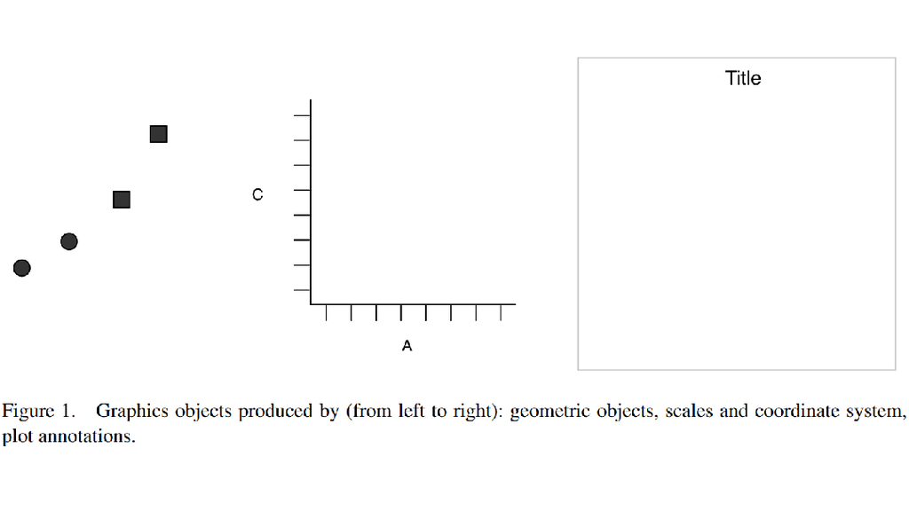

Source: Wickham, H. (2010). “A Layered Grammar of Graphics.”

### "The Grammar of Graphics"

> “The grammar of graphics takes us beyond a limited set of charts (words) to an almost unlimited world of graphical forms (statements).  
> -Wilkinson, L. (2005), p.1”

### Wilkinson's "grammar"

Wilkinson's idea is implemented in the Graphics Production Language (GPL) and has the following components:

- Data
- Transformation
- Element
- Scale
- Guide
- Coordinate system

## ggplot2 package

### Motivation

> This article proposes an alternative parameterization of the [graphical] grammar, based around the idea of building up a graphic from multiple layers of data. The grammar differs from Wilkinson's in its arrangement of the components, the development of a hierarchy of defaults, and in that it is embedded inside another programming language.  
> -Wickham, H. (2010), p.4

### Comparison

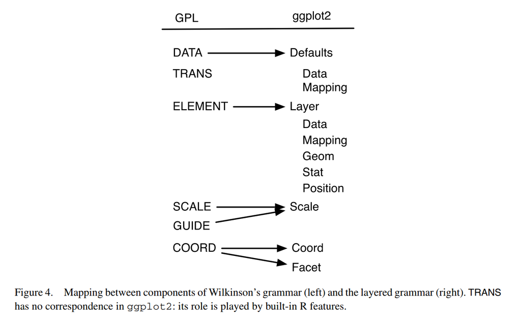

Source: Wickham, H. (2010). “A Layered Grammar of Graphics.”

### Basic components

- Data and aesthetic mappings
- Geometic objects
- Labels

### Data and aesthetic mappings

```r
# data and aesthetics
ggplot(data, mapping = aes(x, y, ...))
```

- `data` is a data frame object (or its variant)
- `mapping` defines aesthetic mappings of data
  - input is an output of the `aes()` function
  - `x` and `y` are columns in `data` input to be mapped to the x-axis and y-axis

**`aes` components**

| `aes` component | Description | Input |
| --- | --- | --- |
| `colour` | Border color | Name (`"red"`), rgb specification (`#FF0000`), or `NA` |
| `fill` | Fill color | Name (`"red"`), rgb specification (`#FF0000`), or `NA` |
| `shape` | Shape of a point | An integer value 0 to 24, or `NA` |
| `linetype` | Linetype | An integer value 0 to 6 or a string |
| `size` | Size of line/point | A non-negative numeric value |
| `alpha` | Transparency | A numeric value 0 to 1 |

**`ggplot2` aesthetics**

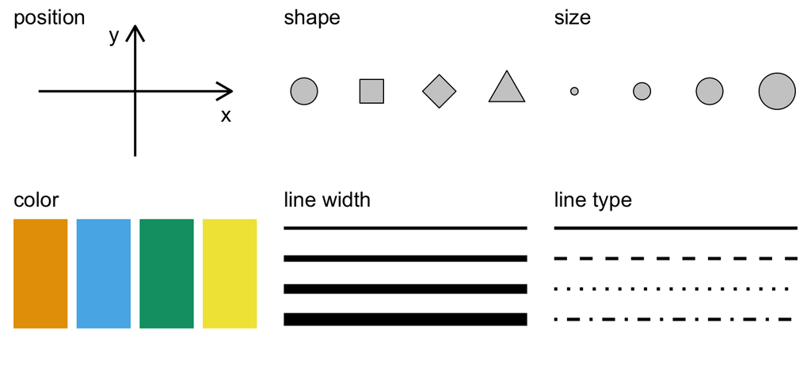

Source: [Figure 1.1](http://serialmentor.com/dataviz/aesthetic-mapping.html) in Wilke, C. (n.d).Data Visualiation.

**`shape` values**

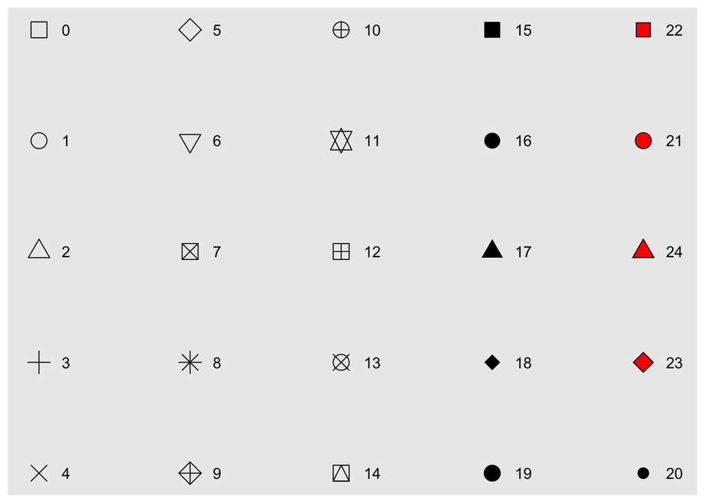

Source: Tidyverse. (n.d.). [“Aesthetic specifications”](http://ggplot2.tidyverse.org/articles/ggplot2-specs.html). ggplot2.tidyverse.org.

**`linetype` values**

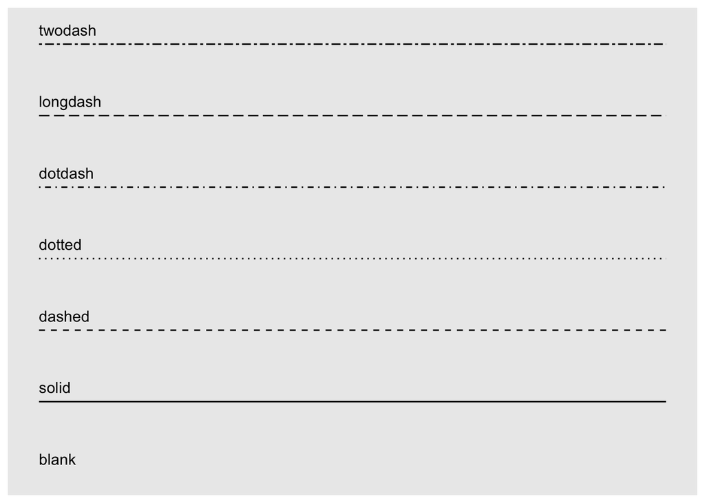

Source: Tidyverse. (n.d.). [“Aesthetic specifications”](http://ggplot2.tidyverse.org/articles/ggplot2-specs.html). ggplot2.tidyverse.org.

### Geometric objects

```r
# adding one or more geometric objects
ggplot(data, aes(x, y, ...)) +
  geom_*()

# with geom_specific `aes`
ggplot(data) +
  geom_*(aes(x, y, ...))
```

- There are many geometric objects, or `geom`s for different graph types:
- Each `geom` can take its own `mapping` input
  - Default is inheriting `mapping` input from `ggplot()`
  - All `aes` specifications can be directly provided for each `geom`

**Basic `geom`s**

| geom | Description | Input |
| --- | --- | --- |
| `geom_histogram` | Histograms | Continous `x` |
| `geom_bar` | Bar plot with frequncies | Discrete `x` |
| `geom_col` | Bar plot with values | Discrete x and continuous `y` |
| `geom_point` | Points/scattorplots | Discrete/continuous `x` and `y` |
| `geom_jitter` | Jittered points | Discrete/continuous `x` and `y` |
| `geom_line` | Line plots | Discrete/continuous x and y |
| `geom_abline` | Reference line | `intercept` and `slope` value |
| `geom_hline`, `geom_vline` | Reference lines | `xintercept` or `yintercept` |

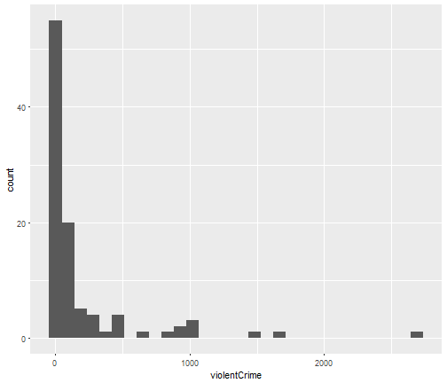

```r
# geom histogram example
data <- ispcrime %>% filter(year == 2015, county != "Cook")
ggplot(data, aes(violentCrime)) +
  geom_histogram()
```

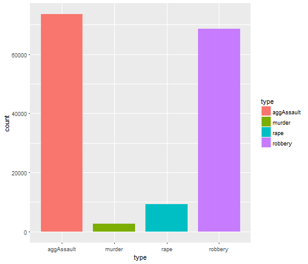

```r
# geom col example
data <- ispcrime %>% filter(county == "Cook") %>% gather("type", "count", murder:aggAssault)
ggplot(data, aes(type, count, fill = type)) +
  geom_col(width = 0.8)
```

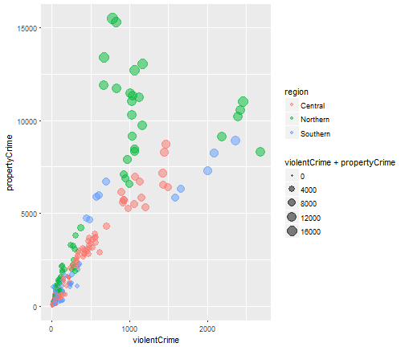

```r
# geom point example
data <- ispcrime %>% filter(county != "Cook") %>% left_join(regions)
ggplot(data, aes(violentCrime, propertyCrime, color = region)) +
  geom_point(aes(size = violentCrime + propertyCrime), alpha = .5)
```

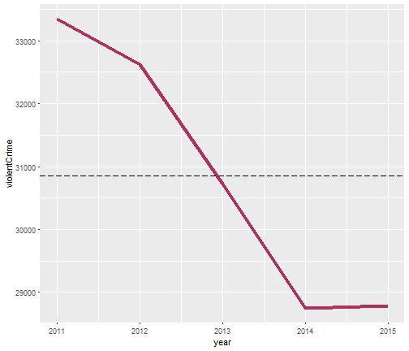

```r
# geom line example
data <- ispcrime %>% filter(county == "Cook")
ggplot(data, aes(year, violentCrime)) +
  geom_line(color = "maroon", size = 1.5) +
  geom_hline(yintercept = mean(data$violentCrime), linetype = "longdash")
```

**Other `geom`s**

| geom | Description | Input |
| --- | --- | --- |
| `geom_density` | Smoothed density estimates | Continous `x` |
| `geom_density2d` | Contours of a 2-d density estimates | Continous `x` |
| `geom_boxplot` | Box plots | Disc. `x` and cont. `y` |
| `geom_smooth` | Smoothed conditional means |  |
| `geom_text`, `geom_label` | Text |  |
| `geom_polygon` | Polygons |  |

- See [the official reference page](http://ggplot2.tidyverse.org/reference/index.html#section-layer-geoms) for the full list of `geom`s.

### Labels

```r
# adding labels
plot + labs(title, subtitle, caption, x, y, ...)
```

- Each argument of `labs()` take a character vector of length 1
  - `title` and `subtitle` appear at the top-left.
  - `caption` appears at the bottom-right
  - `x` and `y` are for x-axis and y-axis names
- Adjusting the position and style of labels is handled via `theme()`

**alternatively …**

```r
plot +
  xlab(label) +
  ylab(label) +
  ggtitle(label, subtitle = NULL)
```

- Each argument of the `labs()` can be added with a separate function.
  - `xlab()` is for x-axis name
  - `ylab()` is for y-axis name
  - `ggtitle()` is for plot title and subtitle

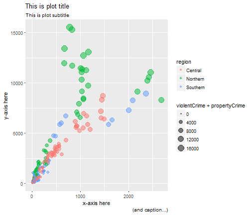

```r
# a generic example with title, subtitle, and axes names
plot +
  labs(
    title = "This is plot title", subtitle = "This is plot subtitle",
    x = "x-axis here", y = "y-axis here",
    caption = "(and caption...)"
  )
```

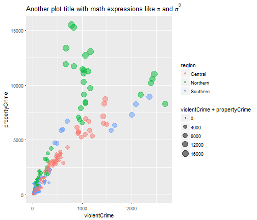

```r
# a title with mathematical expressions
plot +
  ggtitle(label = expression(paste("Another plot title with math expressions like ", pi, " and ", sigma^{2})))
```

### Additional components

- Scales
- Guides
- Facets
- Coordinate systems
- Themes

### Scales

- Scales control “the details of how data values are translated to visual properties”
- Scale limits
- Position scales (discrete, continuous, datetime)
- Others

**Scale limits**

```r
plot +
  xlim(...) +
  ylim(...) +
  lims(...)
```

- `xlim()` changes x-axis limits
- `ylim()` changes y-axis limits
- `lims()` is a general function to change limits
- `...` in `xlim()` and `ylim()` are numeric values to set lower and upper limit for the corresponding axis
- `...` in `lims()` is a name-value pair, where the name is an aesthetic and the value is either a length-2 numeric, a character, a factor, or a datetime

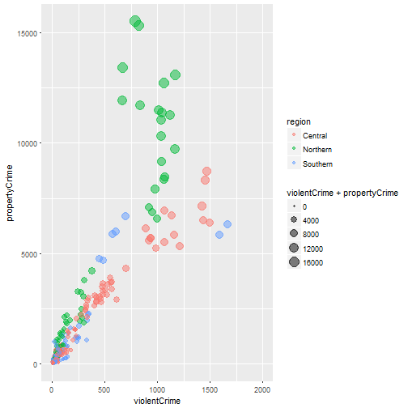

```r
# limit x axis to 2000 at the top;
# this removes points with violentCrime > 2000
plot + xlim(NA, 2000)
```

**Position scales (continuous)**

```r
scale_x_continuous(..., expand = waiver(), trans = "identity", position = "bottom")
scale_y_continuous(..., expand = waiver(), trans = "identity", position = "left")

# shortcuts for common transformations
scale_x_log10(...)
scale_y_log10(...)

scale_x_sqrt(...)
scale_y_sqrt(...)

scale_x_reverse(...)
scale_y_reverse(...)
```

**Common scale_* arguments**

| Argument | Description |
| --- | --- |
| `name` | a name of the scale, used as the axis label or the legend title |
| `breaks` | controls the breaks in the guide, which can be a character vector |
| `labels` | controls the lable for each break; its input must be the same length as `breaks` input |
| `limits` | a character vector specifying the data range for the scale |

**Position scales (discrete)**

```r
scale_x_discrete(..., expand = waiver(), position = "bottom")
scale_y_discrete(..., expand = waiver(), position = "left")
```

**Position scales (datetime)**

```r
scale_x_date(...)
scale_y_date(...)

scale_x_datetime(...)
scale_y_datetime(...)

scale_x_time(...)
scale_y_time(...)
```

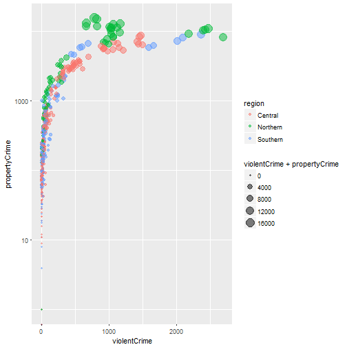

```r
# apply the log 10 scale to the y-axis
plot + scale_y_log10()
```

**Custom scale “manuals”**

```r
scale_*_manual(name, breaks, labels, limits, ..., values)
```

- Scale manuals is used to create my own discrete scale
- “Manual” is available for:
  - `colour`
  - `fill`
  - `size`
  - `shape`
  - `linetype`
  - `alpha`

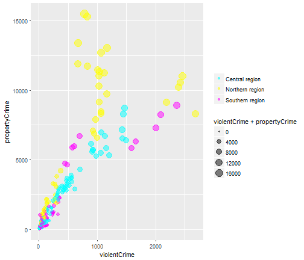

```r
plot + scale_color_manual(
  name = "",
  breaks = c("Central", "Northern", "Southern"),
  labels = c("Central region", "Northern region", "Southern region"),
  values = c("#00ffff", "#ffff00", "#ff00ff")
)
```

**Other custom scales**

`ggplot2` offers many more functions to customize scales.

See the full documentation on scales [here](http://ggplot2.tidyverse.org/reference/#section-scales).

### Guides

```r
guides(...)
guide_legend(...)
guide_colourbar() # equivalent to guide_colorbar()
```

- `guides` can be used to set (or remove) guides for each scale
- `guide_legend()` can be used to specify the legend components for each visual properties (e.g. `colour`, `size`, `alpha`, etc.)
- `guide_colourbar()` or `guide_colorbar()` controls the continous color bar
- `guide_legned()` and `guide_colourbar()` can be used as an input for each scale argument in `guide()`

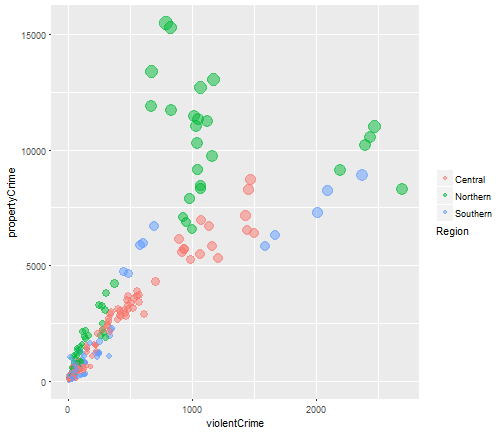

```r
plot + guides(
  colour = guide_legend(title = "Region", title.position = "bottom"),
  size = FALSE
)
```

### Coordinate systems

```r
plot + coord_cartesian()
```

- The default system is `coord_cartesian`
  - Can be tweatked with: `coord_fixed`, `coord_flip`, `coord_map` and `coord_trans`
- An alternative, polar coordiante system can be used with `coord_polar`
  - Most commonly used for creating a pie chart

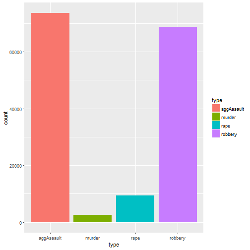

```r
# default plot
plot
```

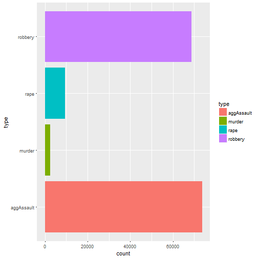

```r
# with coord_flip()
plot + coord_flip()
```

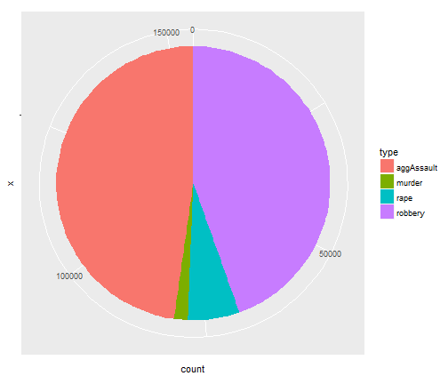

```r
# pie chart with coord_polar()
ggplot(ispcrime %>% filter(county == "Cook") %>% gather("type", "count", murder:aggAssault), aes("", count, fill = type)) +
  geom_col(width = 1) +
  coord_polar("y")
```

### Facets

```r
plot + facet_grid(facets, scales, ...)
plot + facet_wrap(facets, nrow, ncol, scales, ...)
```

- A great way to visualize multi-dimensional data as a series of 2D graphes
- `facets` input takes a “formula” according to which the faceting is applied

**facet_grid vs facet_wrap**

- `facet_grid()` and `facet_wrap()` are mostly similar to each other
- However, they differ where:
  - `facet_grid()` facets the plot with a variable in a single direction (horizontal or vertical)
  - `facet_wrap()` simply places the facets next to each other and wraps them accoridng to the provided number of columns and/or rows.

**facet formulas**

| Type | Formula | Description |
| --- | --- | --- |
| Grid | `facet_grid(. ~ x)` | Facet horizontally across `x` values |
| Grid | `facet_grid(y ~ .)` | Facet vertically across `y` values |
| Grid | `facet_grid(y ~ x)` | Facet 2-dimensionally |
| Wrap | `facet_wrap(~ x)` | Facet across `x` values |
| Wrap | `facet_wrap(~ x + y)` | Facet across `x` and `y` values |

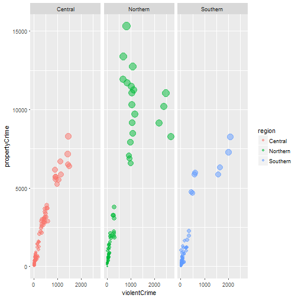

```r
# facet_grid horizontal
plot + facet_grid(. ~ region)
```

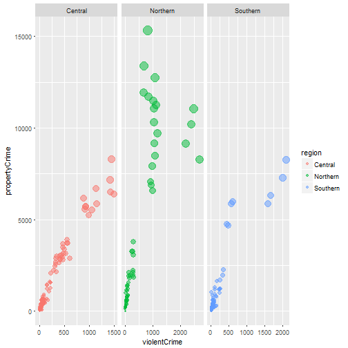

```r
# facet_grid horizontal with free scales
plot + facet_grid(. ~ region, scales = "free")
```

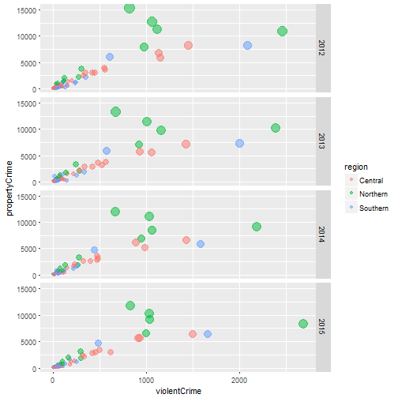

```r
# facet_grid vertical
plot + facet_grid(year ~ .)
```

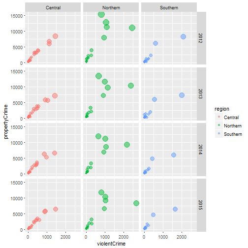

```r
# facet_grid two-dimensional
plot + facet_grid(year ~ region)
```

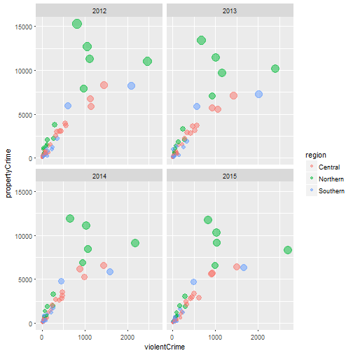

```r
# facet wrap
plot + facet_wrap(~ year)
```

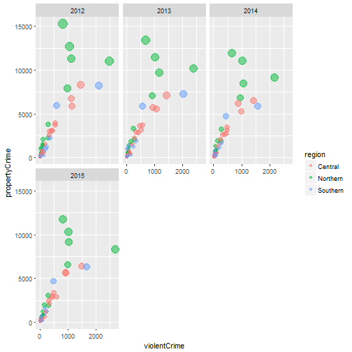

```r
# facet wrap with specified nrow/ncol
plot + facet_wrap(~ year, ncol = 3)
```

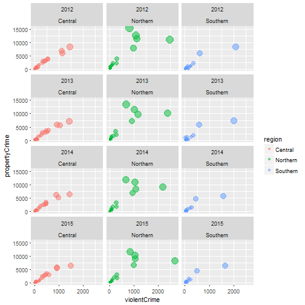

```r
# facet wrap with multiple variables
plot + facet_wrap(~ year + region, ncol = 3)
```

### Themes

```r
# themes
plot + theme_gray(base_size = 11, base_family = "")
```

- `ggplot2` offers several predefined themes
  - the default theme is `theme_gray()` (or `theme_grey()`)
  - `base_size` controls the base font size
  - `base_family` controls the base font family (“serif”, “sans”, “mono”)
- `ggthemes` pacakge offers additional predefined themes

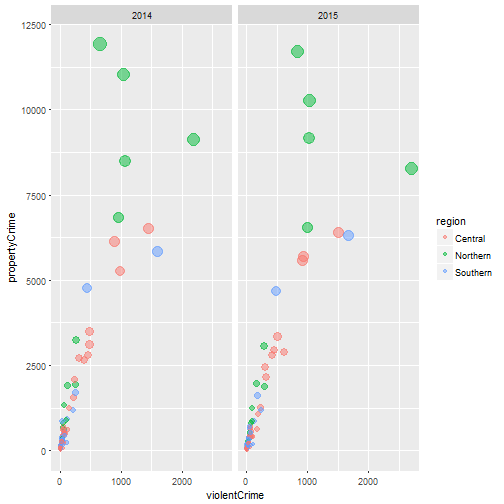

```r
plot + theme_gray() # this is the default
```

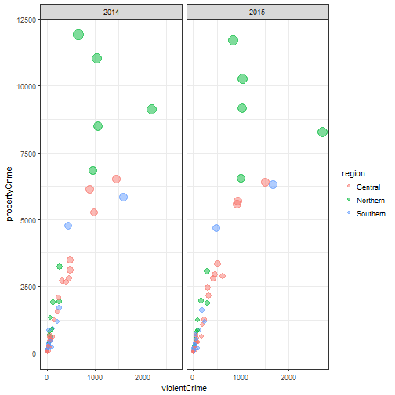

```r
plot + theme_bw()
```

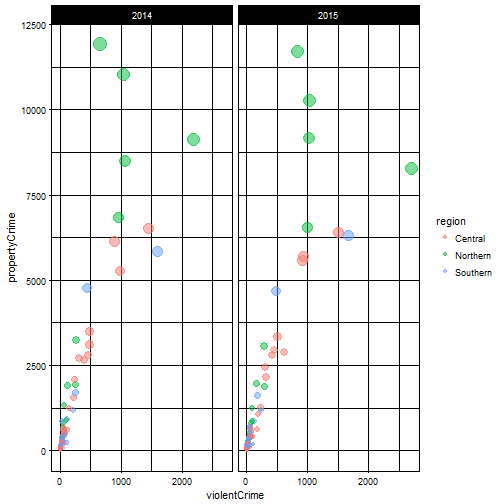

```r
plot + theme_linedraw()
```

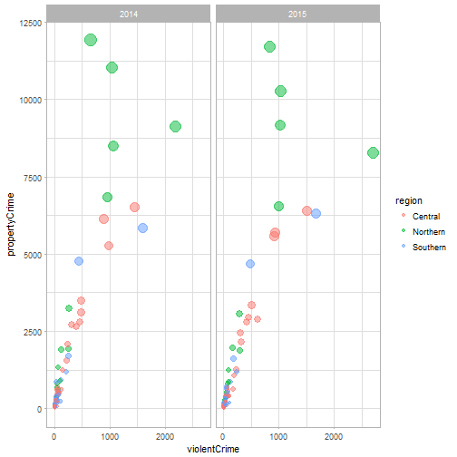

```r
plot + theme_light()
```

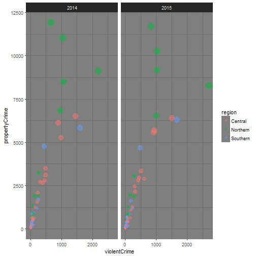

```r
plot + theme_dark()
```

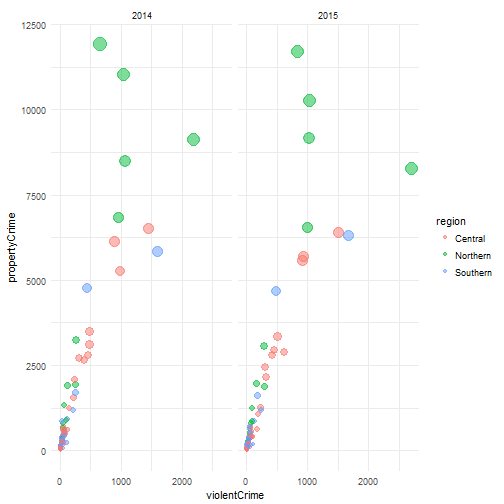

```r
plot + theme_minimal()
```

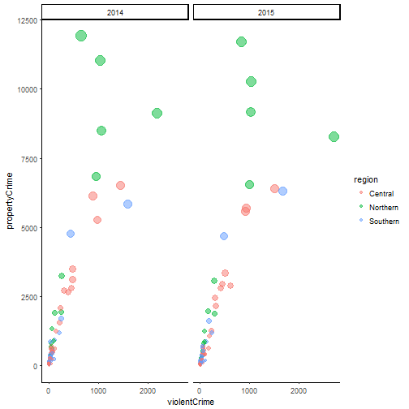

```r
plot + theme_classic()
```

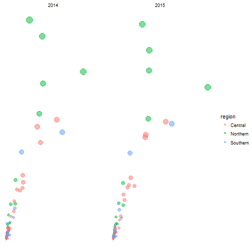

```r
plot + theme_void()
```

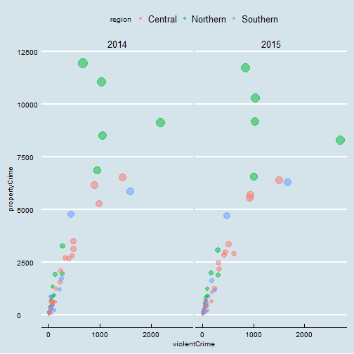

```r
plot + ggthemes::theme_economist()
```

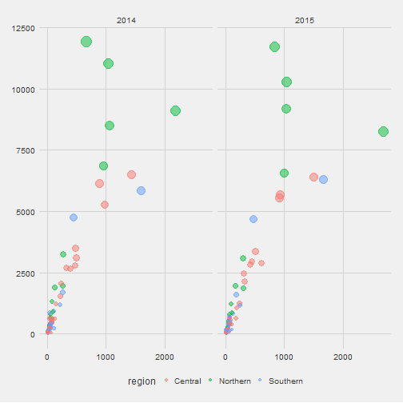

```r
plot + ggthemes::theme_fivethirtyeight()
```

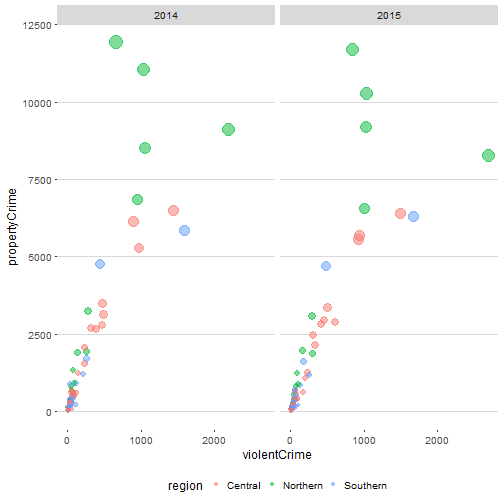

```r
plot + ggthemes::theme_hc()
```

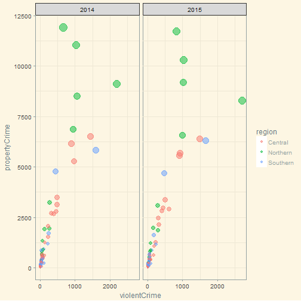

```r
plot + ggthemes::theme_solarized()
```

```r
plot + theme(...)
```

- `theme` has arguments to control and motify individual components of a plot theme:
  - all line, rectangular, text and title elements
  - aspect ratio of the panel
  - axis title, text, ticks, and lines
  - legend background, margin, text, title, position, and more
  - panel aspect ratio, border, and grid lines
  - and more
- Read the full documentation [here](http://ggplot2.tidyverse.org/reference/theme.html)

### ggplot2 resources

- Chang, W. [*R Graphics Cookbook*](http://www.cookbook-r.com/Graphs/).
- Emaasit, D. [*`ggplot2` extentions*](http://www.ggplot2-exts.org/index.html).
  - A list of R pacakges extending `ggplot2`
- Prabhakaran, S. [“How to make any plot in `ggplot2`?”](http://r-statistics.co/ggplot2-Tutorial-With-R.html). *r-statistics.co*.
- RStudio. [“Data Visualization Cheat Sheet”](https://github.com/rstudio/cheatsheets/raw/master/data-visualization-2.1.pdf).
- Tidyverse. [“Reference”](http://ggplot2.tidyverse.org/reference/index.html). *ggplot2.tidyverse.org*.
- Wilke, C. [*Fundamentals of Data Visualization*](http://serialmentor.com/dataviz/).

## Questions?

[figure not shown]

Source: [tenor.com](https://tenor.com/view/mario-question-block-super-mario-gif-7732885)

References

- Grolemund, G. & Wickham, H. (2017).[“Data visualization”](http://r4ds.had.co.nz/data-visualisation.html). R for Data Science
- Tidyverse. (n.d.). [“References”](http://ggplot2.tidyverse.org/reference). ggplot2.tidyverse.org
- Wickham, H. (2010). “A Layered Grammar of Graphics”. Journal of Computational and Graphical Statistics 19(1):3-28.
- Wilkinson, L. (2005). The Grammar of Graphics.
- Wilkinson, L., Rope, D., Carr, D. & Rubin, M. (2000). “The Language of Graphics”. Journal of Computational and Graphical Statistics 9(3):530-543.

[figure not shown]

Source: [Wikimedia.org](https://www.wikimedia.org)